# Final Individual Summary Report

## Income Quintile Comparisons

Income quintile comparisons provide a clearer, aggregated view of how housing complaint rates vary across the income distribution. Bar charts summarizing average complaints per capita by income quintile show that the lowest-income quintiles (1 through 3) do not exhibit the highest reporting rates. Instead, higher-income neighborhoods�particularly those in the fourth and fifth income quintiles�consistently demonstrate higher average complaint rates per resident. Census tracts with missing income data also display elevated complaint rates, likely reflecting data gaps in high-density or transitional areas rather than a distinct income effect.

These results challenge the common assumption that lower-income neighborhoods dominate housing complaint systems. While lower-income tracts often face more severe housing conditions, they report fewer complaints per resident on average. In contrast, higher-income residents appear more likely to file complaints, even when underlying housing quality is relatively better. This pattern suggests that complaint frequency is shaped not only by housing conditions, but also by differences in civic engagement, access to reporting tools, awareness of tenant rights, and expectations regarding housing quality across income groups.

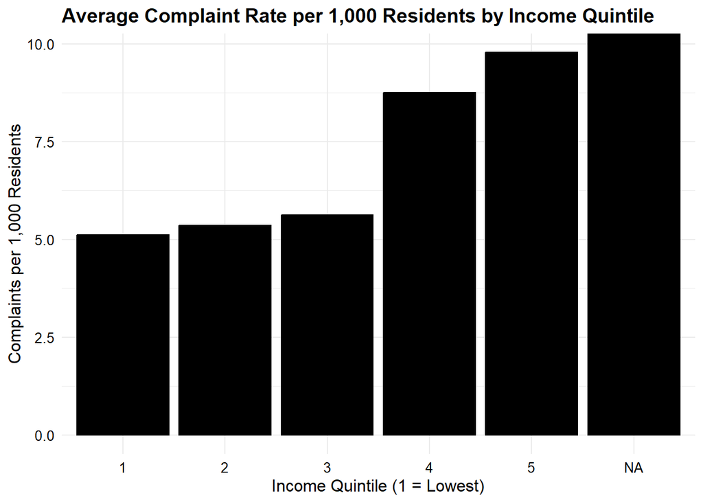

```r
# Bar chart: average complaint rate by income quintile
tract_master %>%
  group_by(income_quintile) %>%
  summarize(mean_rate = mean(complaints_per_1000_pop, na.rm = TRUE)) %>%
  ggplot(aes(x = factor(income_quintile), y = mean_rate)) +
  geom_col(fill = "black", color = "black") +   # solid black bars
  labs(
    title = "Average Complaint Rate per 1,000 Residents by Income Quintile",
    x     = "Income Quintile (1 = Lowest)",
    y     = "Complaints per 1,000 Residents"
  ) +
  theme_minimal(base_family = "sans") +
  theme(
    plot.title    = element_text(size = 14, face = "bold", color = "black"),
    axis.title.x  = element_text(size = 12, color = "black"),
    axis.title.y  = element_text(size = 12, color = "black"),
    axis.text     = element_text(size = 10, color = "black")
  )
```

```r
# ============================================================
# Final filtered dataset for modeling (SQ1+)
#     - Keep tracts with enough population and units
# ============================================================

tract_s1 <- tract_master %>%
  filter(
    !is.na(income),
    !is.na(population),
    !is.na(complaints_311),
    population    >= 500,
    housing_units >= 100
  ) %>%
  mutate(
    complaints_per_1000_pop   = complaints_311 / population * 1000,
    complaints_per_1000_units = complaints_311 / housing_units * 1000,
    income_quintile           = ntile(income, 5)
  )
```

The map illustrates population-normalized 311 complaint rates across New York City census tracts, highlighting patterns of civic engagement and housing stress. Yellow areas represent tracts with the highest per capita complaint rates, signaling either elevated housing distress or active resident reporting. In contrast, dark blue areas indicate tracts with lower complaint rates, which may reflect fewer reported issues or reduced engagement. By normalizing complaints by population, the visualization controls for tract size, allowing for a clearer comparison of reporting frequency rather than raw volume.

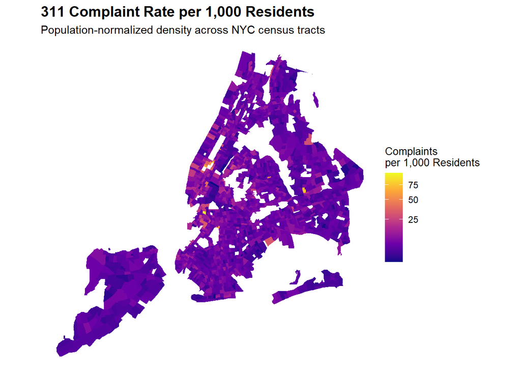

```r
# Map complaint rate in the cleaned analysis sample
ggplot(tract_s1) +
  geom_sf(aes(fill = complaints_per_1000_pop), color = NA) +
  scale_fill_viridis_c(
    option   = "plasma",       # vibrant and readable gradient
    trans    = "sqrt",         # softens skew in complaint rates
    na.value = "grey90",
    name     = "Complaints\nper 1,000 Residents"
  ) +
  labs(
    title    = "311 Complaint Rate per 1,000 Residents",
    subtitle = "Population-normalized density across NYC census tracts"
  ) +
  theme_void() +               # removes axis ticks and background clutter
  theme(
    plot.title    = element_text(size = 14, face = "bold"),
    plot.subtitle = element_text(size = 11),
    legend.title  = element_text(size = 10),
    legend.text   = element_text(size = 9),
    legend.position = "right"
  )
```

Slight upward trend suggests positive correlation as income increases, complaint rate per capita rise Regardless of income majority of neighborhoods report fewer than 50 complaints per 1000 residents Outliers exists at both ends.

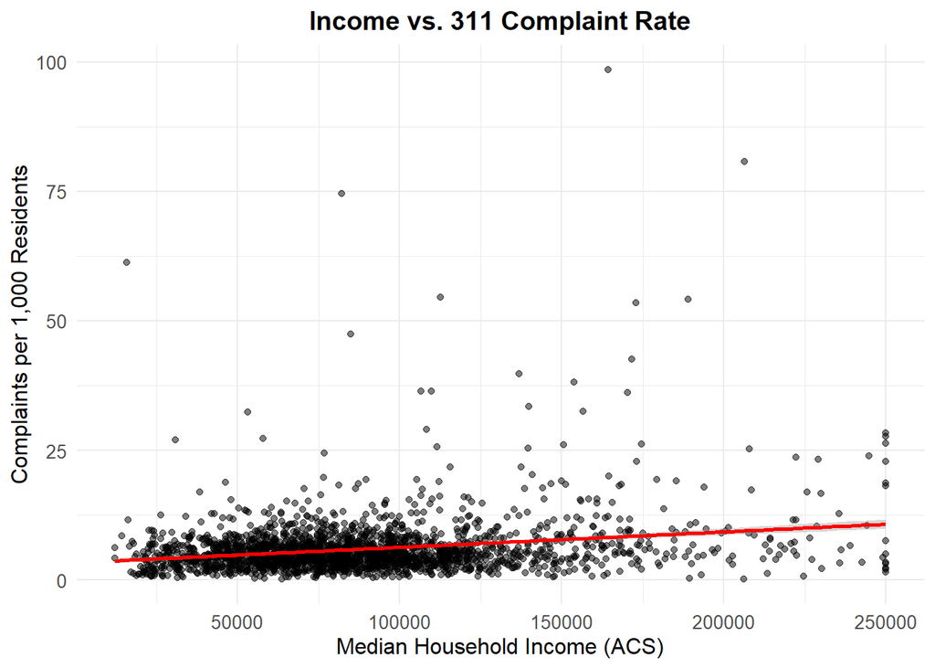

```r
# Simple scatterplot: income vs complaints per 1,000 population
ggplot(tract_s1, aes(income, complaints_per_1000_pop)) +
  geom_point(alpha = 0.5) +
  geom_smooth(method = "lm", color = "red") +
  labs(
    title = "Income vs. 311 Complaint Rate",
    x     = "Median Household Income (ACS)",
    y     = "Complaints per 1,000 Residents"
  ) +
  theme_minimal() +
  theme(
    plot.title = element_text(size = 14, face = "bold", hjust = 0.5),
    axis.title.x = element_text(size = 12),
    axis.title.y = element_text(size = 12),
    axis.text    = element_text(size = 10)
  )
```

Complaint rates tend to increase with income, as evidenced by Quintile 5�the highest income group�showing the highest average complaint rate. In contrast, Quintiles 1 through 4 remain relatively flat, indicating minimal variation among lower and middle-income tracts. While the upward slope is modest, it is consistent, suggesting that higher-income neighborhoods report more complaints per capita on average. This pattern may reflect greater civic engagement, heightened expectations for housing quality, and improved access to reporting tools among wealthier residents.

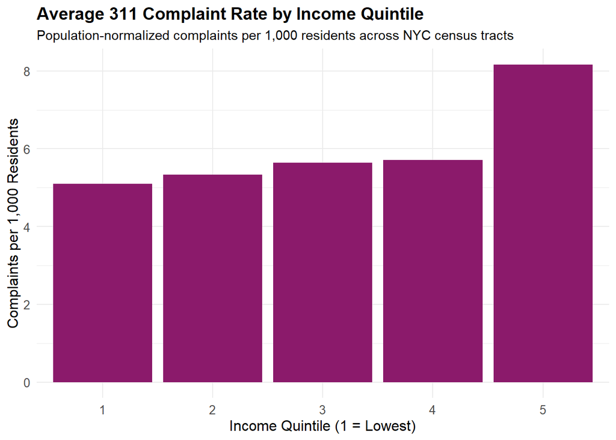

```r
# Bar chart: average complaint rate per income quintile
tract_s1 %>%
  group_by(income_quintile) %>%
  summarize(mean_rate = mean(complaints_per_1000_pop, na.rm = TRUE)) %>%
  ggplot(aes(x = factor(income_quintile), y = mean_rate)) +
  geom_col(fill = "#8B1A6B") +
  labs(
    title    = "Average 311 Complaint Rate by Income Quintile",
    subtitle = "Population-normalized complaints per 1,000 residents across NYC census tracts",
    x        = "Income Quintile (1 = Lowest)",
    y        = "Complaints per 1,000 Residents"
  ) +
  theme_minimal() +
  theme(
    plot.title    = element_text(size = 14, face = "bold"),
    plot.subtitle = element_text(size = 11),
    axis.title.x  = element_text(size = 12),
    axis.title.y  = element_text(size = 12),
    axis.text     = element_text(size = 10)
  )
```

# 5. Analytical Modeling

## Regression and Predictive Modeling

To move beyond descriptive analysis, the study employs both linear regression and a random forest model to predict complaint rates per 1,000 residents. Predictor variables include median household income, rent burden, housing units, population, and borough.

The random forest model is particularly useful because it captures non-linear relationships and interactions that traditional regression may miss. The model is trained on over 2,000 census tracts after filtering for data completeness.

```r
# ============================================================
# SQ1: Random Forest model to predict complaint rate
#       using income + housing + population + borough
# ============================================================
library(ranger)

library(ggplot2)
library(stringr)
library(dplyr)

# Derive borough factor from tract NAME (ACS naming convention)
tract_s1 <- tract_s1 %>%
  mutate(
    borough = case_when(
      str_detect(NAME, "Bronx County")      ~ "Bronx",
      str_detect(NAME, "Kings County")      ~ "Brooklyn",
      str_detect(NAME, "New York County")   ~ "Manhattan",
      str_detect(NAME, "Queens County")     ~ "Queens",
      str_detect(NAME, "Richmond County")   ~ "Staten Island",
      TRUE                                  ~ NA_character_
    )
  )

# Build RF training data: drop geometry, select predictors, remove NAs
rf_data <- tract_s1 %>%
  st_drop_geometry() %>%        # drop sf geometry to get a plain data frame
  select(
    complaints_per_1000_pop,
    income,
    rent_burden,
    housing_units,
    population,
    borough
  ) %>%
  mutate(borough = factor(borough)) %>%
  na.omit()

model_comp1000 <- lm(
  complaints_per_1000_pop ~ income + rent_burden,
  data = rf_data
)


# Fit Random Forest to predict complaint rate per 1,000 inhabitants
set.seed(123)

rf_model <- ranger(
  complaints_per_1000_pop ~ .,
  data       = rf_data,
  num.trees  = 1000,
  mtry       = 3,
  importance = "impurity",
  respect.unordered.factors = "order"
)

rf_model
```

```
Ranger result

Call:
 ranger(complaints_per_1000_pop ~ ., data = rf_data, num.trees = 1000,      mtry = 3, importance = "impurity", respect.unordered.factors = "order")

Type:                             Regression
Number of trees:                  1000
Sample size:                      2176
Number of independent variables:  5
Mtry:                             3
Target node size:                 5
Variable importance mode:         impurity
Splitrule:                        variance
OOB prediction error (MSE):       26.42903
R squared (OOB):                  0.1646447
```

```r
rf_model$variable.importance
```

```
       income   rent_burden housing_units    population       borough
    15300.648     12882.534     10562.813     20451.352      2582.431
```

# 6. Model Interpretation

Model outputs indicate that income remains a meaningful predictor of complaint rates even after controlling for housing supply, population size, rent burden, and borough effects. Partial dependence plots show that predicted complaint rates increase as income rises, holding other variables constant.

This finding reinforces the descriptive results: higher-income neighborhoods are more likely to generate complaints, not because they necessarily have worse housing conditions, but because residents may be more empowered, informed, or willing to engage with municipal reporting systems.

Key Takeaways: - The Output shows that the Random Forest model predicted 311 complaint rate per 1k residents - The model trained on 2,176 census tracts using - income - Rent_Burden - Housing_units - population - Borough (factor)

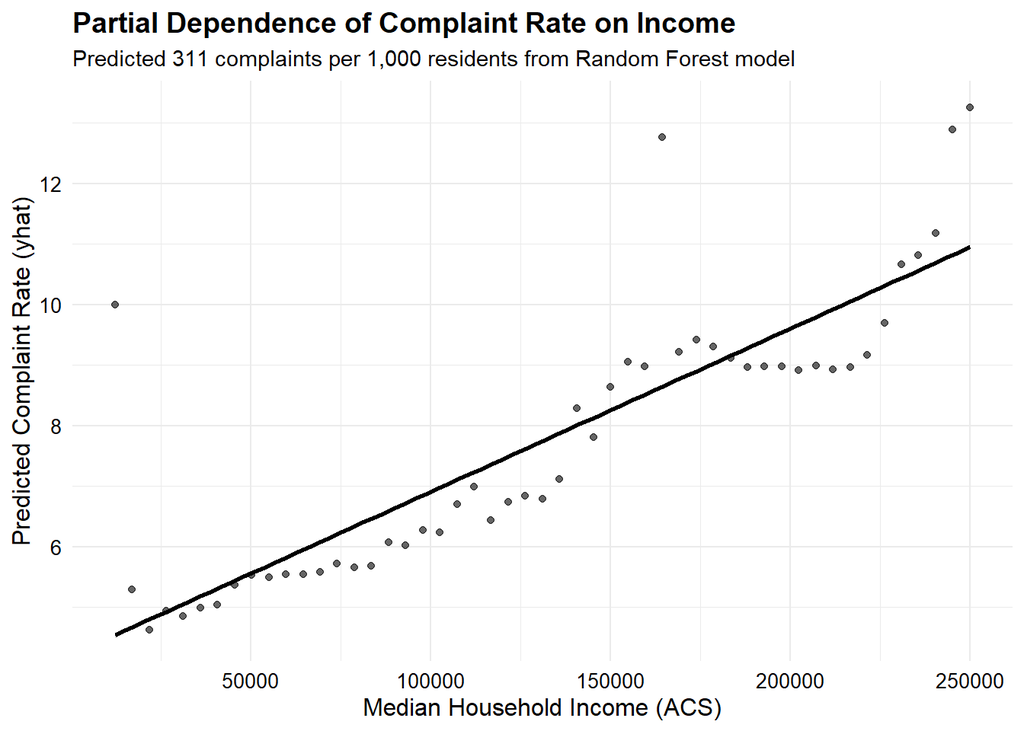

```r
# ============================================================
# Partial Dependence Plot (PDP) for income in RF model
#       - Shows marginal effect of income holding others fixed
# ============================================================
library(pdp)
library(ggplot2)

pdp_income <- partial(rf_model, pred.var = "income", train = rf_data)

ggplot(pdp_income, aes(x = income, y = yhat)) +
  geom_point(alpha = 0.6, color = "black") +          # black points
  geom_smooth(method = "lm", color = "black", se = FALSE) +  # black regression line
  labs(
    title    = "Partial Dependence of Complaint Rate on Income",
    subtitle = "Predicted 311 complaints per 1,000 residents from Random Forest model",
    x        = "Median Household Income (ACS)",
    y        = "Predicted Complaint Rate (yhat)"
  ) +
  theme_minimal(base_family = "sans") +
  theme(
    plot.title    = element_text(size = 14, face = "bold", color = "black"),
    plot.subtitle = element_text(size = 11, color = "black"),
    axis.title.x  = element_text(size = 12, color = "black"),
    axis.title.y  = element_text(size = 12, color = "black"),
    axis.text     = element_text(size = 10, color = "black")
  )
```

The partial dependence plot reveals that higher-income areas tend to report more complaints per capita, even when controlling for housing units, population, rent burden, and borough. This pattern supports the notion that civic engagement and expectations increase with income�residents in wealthier neighborhoods may be more inclined to report issues due to greater awareness, access, or advocacy. These findings reinforce earlier insights from scatterplots and bar charts, underscoring that complaint behavior is shaped not only by housing stress but also by who feels empowered to report.

# 7. Answering the Supporting Question and tying back to Main Question

Returning to the supporting question�are housing complaints more concentrated in lower-income neighborhoods?�the evidence from this analysis suggests that the answer is not unequivocal. The concentration of housing complaints depends critically on how those complaints are measured and normalized.

However, a different pattern emerges when complaints are normalized by population or examined through predictive models. Maps and scatterplots normalized per capita consistently show that higher-income neighborhoods often report equal or higher complaint rates per resident. Tracts in Manhattan and Queens, for example, display elevated per-capita reporting despite generally better housing conditions. This divergence reveals a crucial distinction: housing complaints capture reporting behavior as much as they capture housing quality.

These findings extend to resolution outcomes as well. Higher-income neighborhoods not only report more frequently, but their complaints may also receive faster or more consistent follow-up due to greater visibility, stronger advocacy, and fewer institutional barriers. Lower-income neighborhoods, meanwhile, may underreport due to fear of landlord retaliation, limited access to digital reporting tools, or distrust of government systems. As a result, unresolved housing stress in poorer areas may be systematically masked in complaint-based datasets.

## Answer to the Primary Question

Thus, the extent to which neighborhood income levels influence housing complaints is substantial: income not only determines where complaints are concentrated, but also what kinds of issues are reported and how effectively they are resolved. Complaint data therefore reflect both housing conditions and the social dynamics of reporting, making income a critical factor in interpreting the spatial distribution, types, and resolution outcomes of housing complaints in New York City.

# 8. Conclusion

This analysis demonstrates that housing complaints in New York City are not simply concentrated in lower-income neighborhoods. Instead, complaint patterns reflect a complex interaction between housing conditions, neighborhood income, civic engagement, and access to reporting mechanisms.

By integrating multiple administrative datasets with census data and applying rigorous normalization and modeling techniques, this study shows that income influences housing complaints in indirect but powerful ways. Understanding these dynamics is essential for interpreting complaint data responsibly and for designing equitable housing policy interventions.